# Linear Regression Project for grades Data

Prabhath D

December 10, 2017

## Project

[output not shown]

## Solution :

In this project we will make a Linear Regression model to predict the final marks of a student based of the set of Predictors/independent Variables given in the file like by gpa,quiz1,quiz2,quiz3,quiz4,quiz5,total.Let’s first import the file names grades.csv

```r
library(readr)
grades<- read_csv("E:\\Acadgild/Business analytics/Projects/Project--Grades-Linear-Regression-master/grades.csv")
##grades<- read_csv(file.choose()) ##
dim(grades)
```

```
## [1] 105  22
```

```r
colnames(grades) # this will gives us the names of the 22 variables
```

```
##  [1] "Sr_No"     "id"        "lastname"  "firstname" "gender"
##  [6] "ethnicity" "year"      "lowup"     "section"   "gpa"
## [11] "extrc"     "review"    "quiz1"     "quiz2"     "quiz3"
## [16] "quiz4"     "quiz5"     "final"     "total"     "percent"
## [21] "grade"     "passfail"
```

We can see that the data which we have imported has 105 observartions and 22 variables. In these 22 Variables we have continous variables as well as categorial variable. We need to be be concerned with continous or scaled data variables as predictors in order to build our model.Firstly lets study the number of students in diffrent categorial variables

```r
library(psych)
table(grades$gender)       #Based on gender
```

```
##
##  1  2
## 64 41
```

```r
table(grades$ethnicity)    #Based on Ethnicity
```

```
##
##  1  2  3  4  5
##  5 20 24 45 11
```

```r
table(grades$passfail)     #Based on whether pass or fail
```

```
##
##  F  O  P
##  6  1 98
```

These are drawn to check the normality of data in that variable

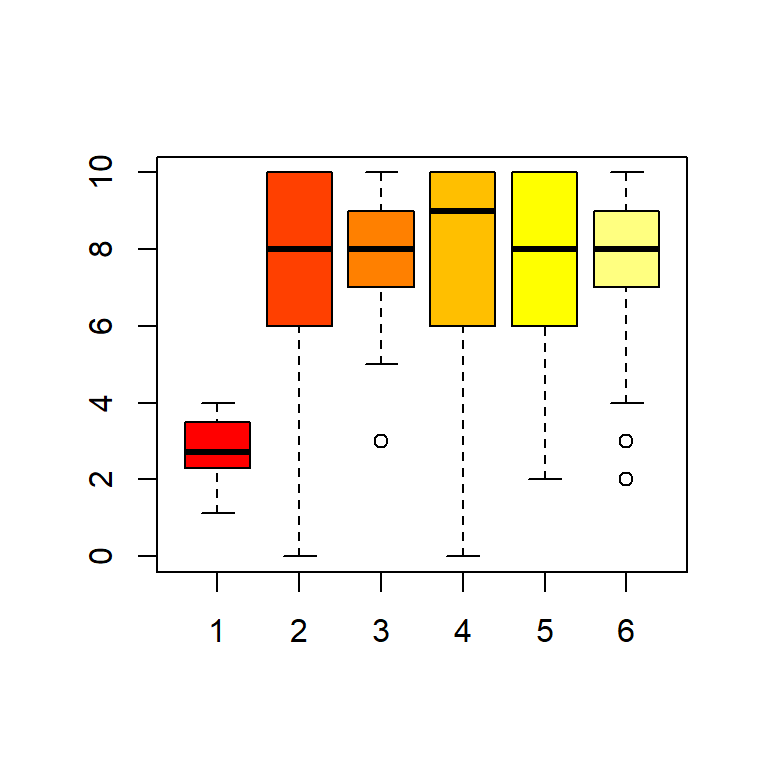

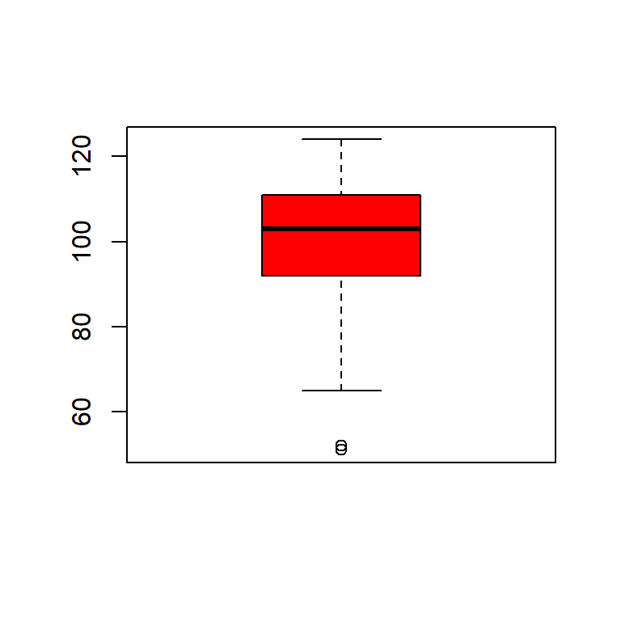

#### Question 1. Describe data of response variable and predictors in terms of key summary statistics like mean, mode, median, standard deviation, range, skewness and kurtosis. Show histogram and box plots also for each variables. [hint: describe command in R]

```
Answer:
```

#### Describing each predictor variable according to the above details

##### Boxplots & Histograms are drawn to check the normality of data for that variable

#### 1. GPA

Data of Gpa saya that mean of GPA is2.78 & sd of GPa is 0.76 Also Mean and trimmed mean, sd and mad are very near hence no outliers, more data on right side and data is platykurtic (meansing it has lighter tails & flat central peak) as shown by kurtosis value.Also skewness value is -0.05 it means it is a bit left skewed or negatively skewed

```
##    vars   n mean   sd median trimmed  mad  min max range  skew kurtosis
## X1    1 105 2.78 0.76   2.72     2.8 0.76 1.14   4  2.86 -0.05    -0.87
##      se
## X1 0.07
```

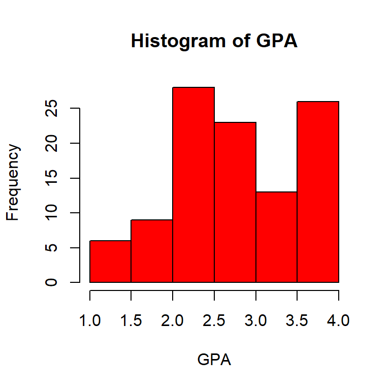

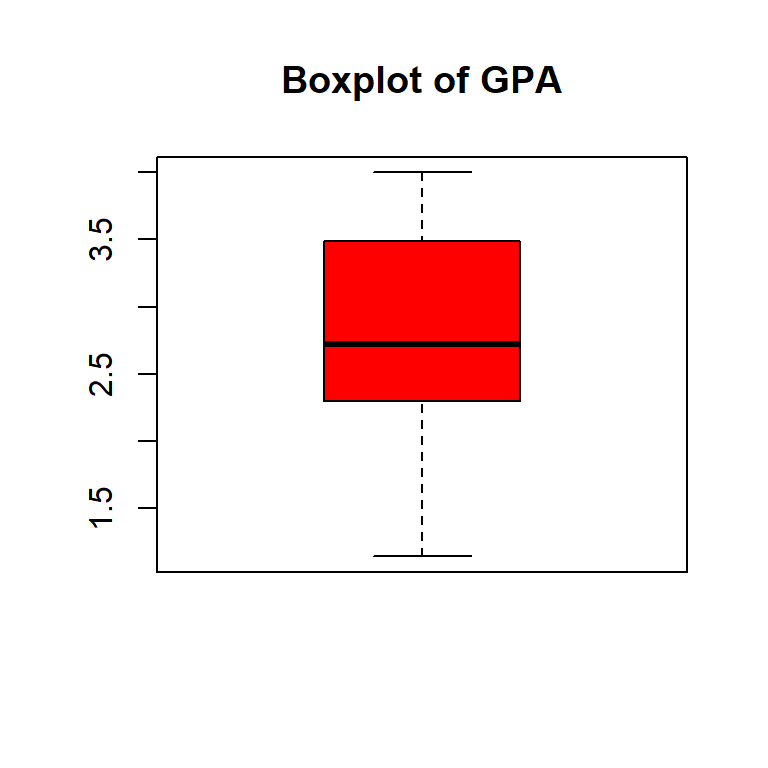

#### 2. Quiz1

Data states that mean is 7.47 sd is 2.48.By the histogram and boxplot we can say that data is skewed towards towards the left that is it is negatively skewed as skewness value is -0.83 also Kurtosis value is 0.04 which is close to 0 hence our data is having heavier tails and sharper peaks an is a leptokurtic distribution.Alsorange of quiz1 is 0 to 10

```
##    vars   n mean   sd median trimmed  mad min max range  skew kurtosis
## X1    1 105 7.47 2.48      8    7.76 2.97   0  10    10 -0.83     0.04
##      se
## X1 0.24
```

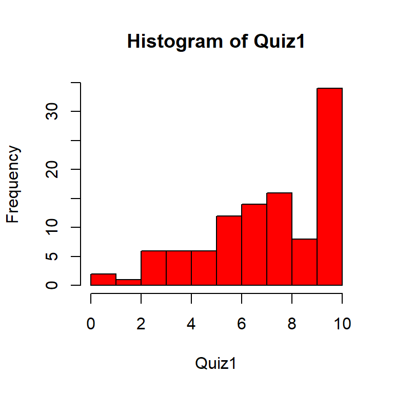

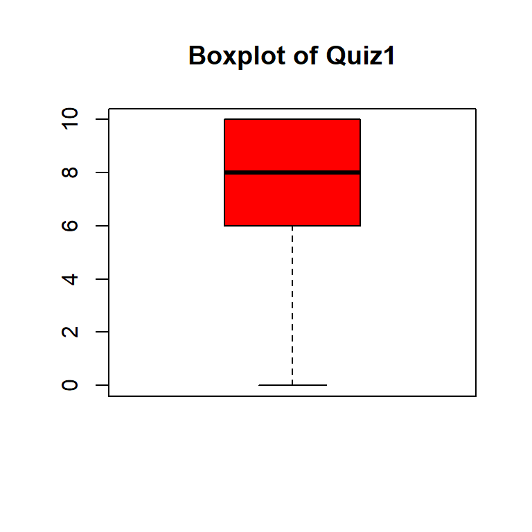

#### 3. Quiz2

Data states that mean value is 7.98 and sd of 1.62. By histogram states that data is skewed little towards the left and boxplot states that data is a almost normally distributed with an outlier in it which is 3 but it is also little skewed towards left.Range of quiz2 is 3 to 10 .Skewness value of -0.64 means a little left skewedkurtosis value of -0.35 means a platykurtic with lighter tails and a flat central peak

```
##    vars   n mean   sd median trimmed  mad min max range  skew kurtosis
## X1    1 105 7.98 1.62      8    8.12 1.48   3  10     7 -0.64    -0.35
##      se
## X1 0.16
```

[figure not shown]

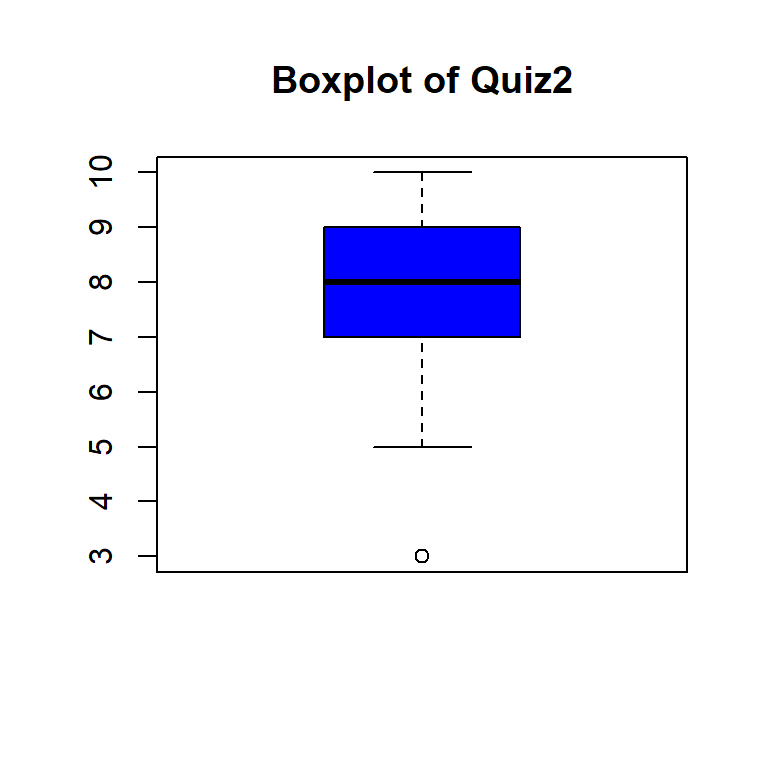

#### 4. Quiz3

Data states that mean value is 7.98 and sd of 2.31(means the observations can have standard dev.of 2.31).By histogram we concluded that data is more towards the left and boxplot states that data is a not normally distributed but completely skewed towards left.Range of quiz3 is 0 to 10 ,Skewness value of -1.1 means data is left skewed .Also kurtosis value of 0.59 means a leptokurtic with heavier tails and a high sharp peak

```
##    vars   n mean   sd median trimmed  mad min max range skew kurtosis   se
## X1    1 105 7.98 2.31      9    8.34 1.48   0  10    10 -1.1     0.59 0.23
```

[figure not shown]

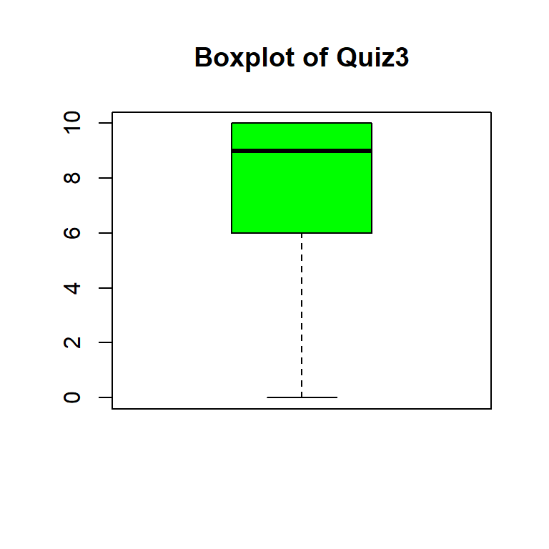

#### 5. Quiz4

```
##    vars   n mean   sd median trimmed  mad min max range  skew kurtosis
## X1    1 105  7.8 2.28      8    8.11 2.97   2  10     8 -0.89    -0.09
##      se
## X1 0.22
```

[figure not shown]

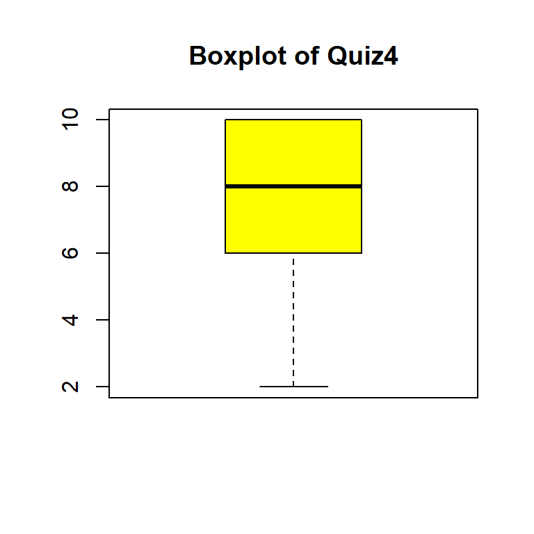

#### 6. Quiz5

```
##    vars   n mean   sd median trimmed  mad min max range  skew kurtosis
## X1    1 105 7.87 1.77      8    8.02 1.48   2  10     8 -0.69     0.16
##      se
## X1 0.17
```

[figure not shown]

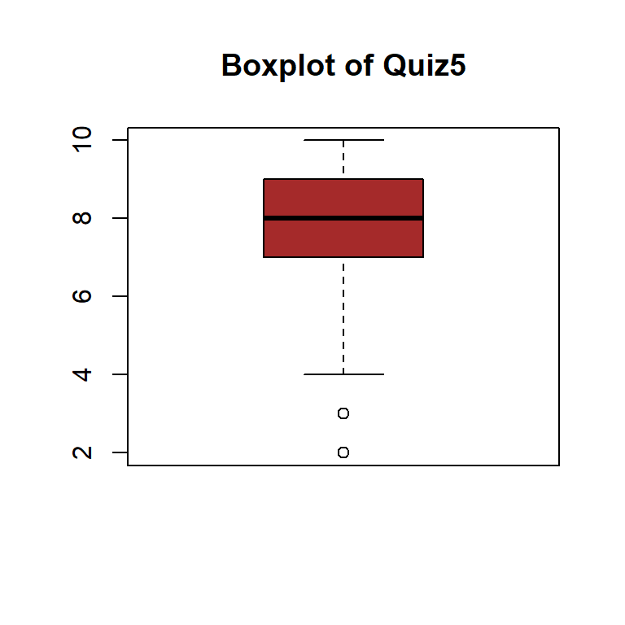

#### 7. Total

```
##    vars   n   mean   sd median trimmed   mad min max range  skew kurtosis
## X1    1 105 100.57 15.3    103   101.8 13.34  51 124    73 -0.81     0.77
##      se
## X1 1.49
```

[figure not shown]

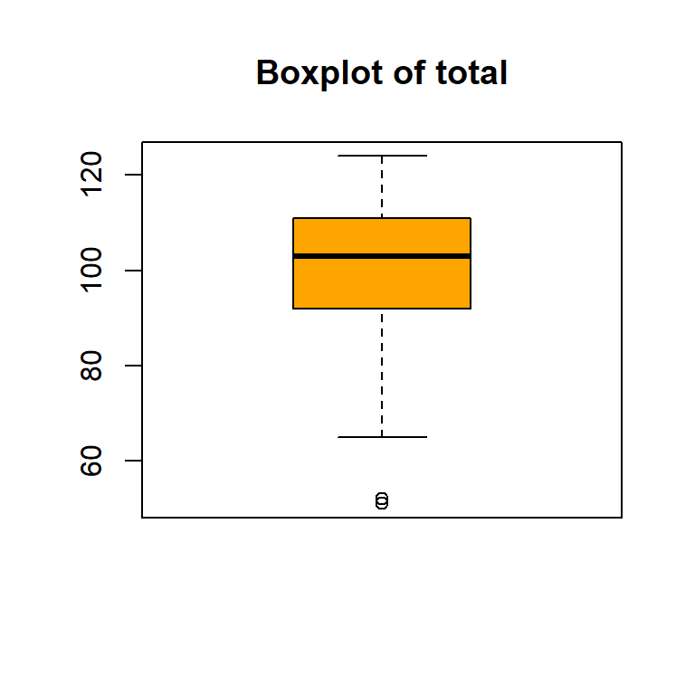

#### 8. Response Variable Final

Data in the final variable states that it has mean of 61.48.final is numeric with range 40-75 which can be seen from min & max.Standard deviation is 7.94 which means that the 68% of the deviations are within the zone of [ 61.47 + 1*7.94] or [61.48- 1*7.94] i.e b/w53.54 & 69.42 whereas 95% of the final observations are in the range [61.48 +- (2 *7.94)] i.e. b/w 45.6 & 77.36 . Median of final is 62 after arranging 62 is the median final score of students. By Histogram we can say that final data is almost normally distributed around its mean but a little skewed towards left and there is an outlier in the data whih is 40. trimmed mean of final is 61.74 .which is obtained by removing the observations which are quite far from the other observations or in one way quite far from the mean. Skewness value of final data is -0.33 which means that the data little towards the left due to outliers present.kurtosis value of -0.42 means that distribution is with light and thinner tails and its central peak is lower and broader when compared with normal distribution.Hence the data is platykurtic as per the Kurtosis value

```
##    vars   n  mean   sd median trimmed mad min max range  skew kurtosis
## X1    1 105 61.48 7.94     62   61.74 8.9  40  75    35 -0.33    -0.42
##      se
## X1 0.78
```

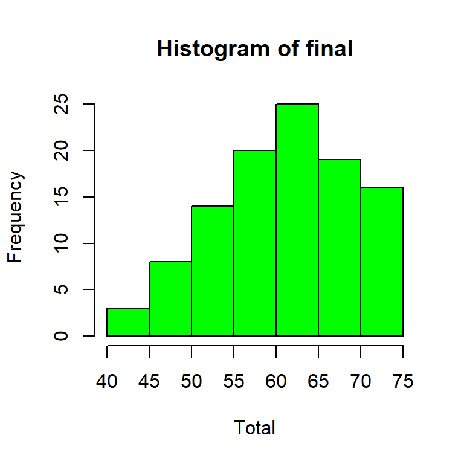

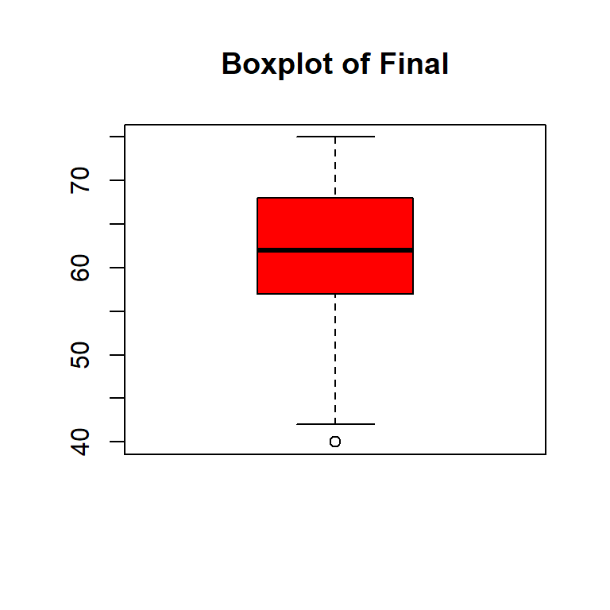

#### Question 2. How predictor/s is related to response variable (final)? .Present diagram/s and correlations in the following space. With diagrams explain relationship .

```
Answer :
```

##### Response Variable or DependentVariable is : final

The scaled variables which can be considered as predictors(x-axis) for predicting the response variable final(dependent variable-y axis) can be

1. gpa
2. quiz1
3. quiz2
4. quiz3
5. quiz4
6. quiz4
7. quiz5
8. total
9. percent

Now let us describe each of these predictors one by one by plotting their scatter plot and try to understand their relationship with final(y)

##### Scatter plots Predictor Vs Response Variable

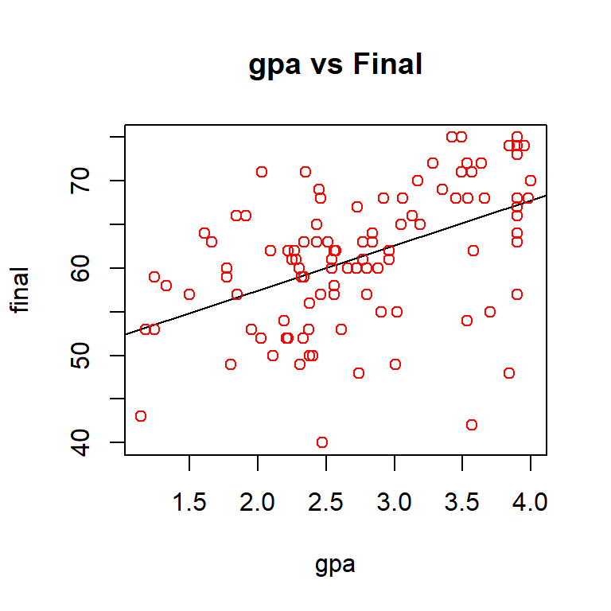

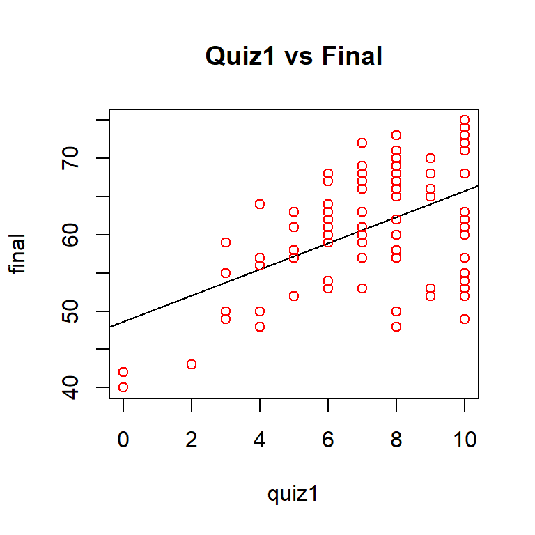

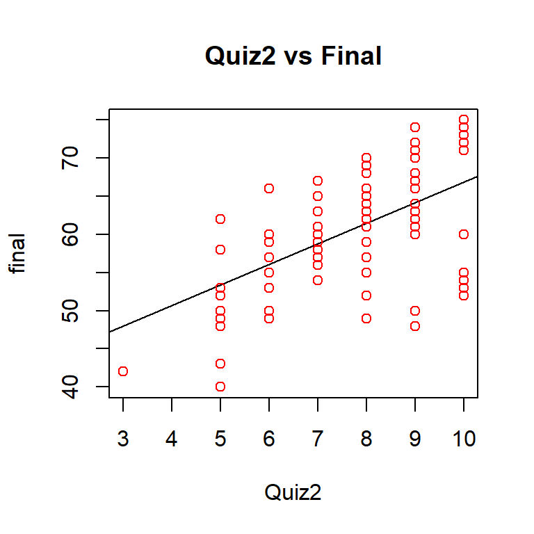

[figure not shown]

[figure not shown]

[figure not shown]

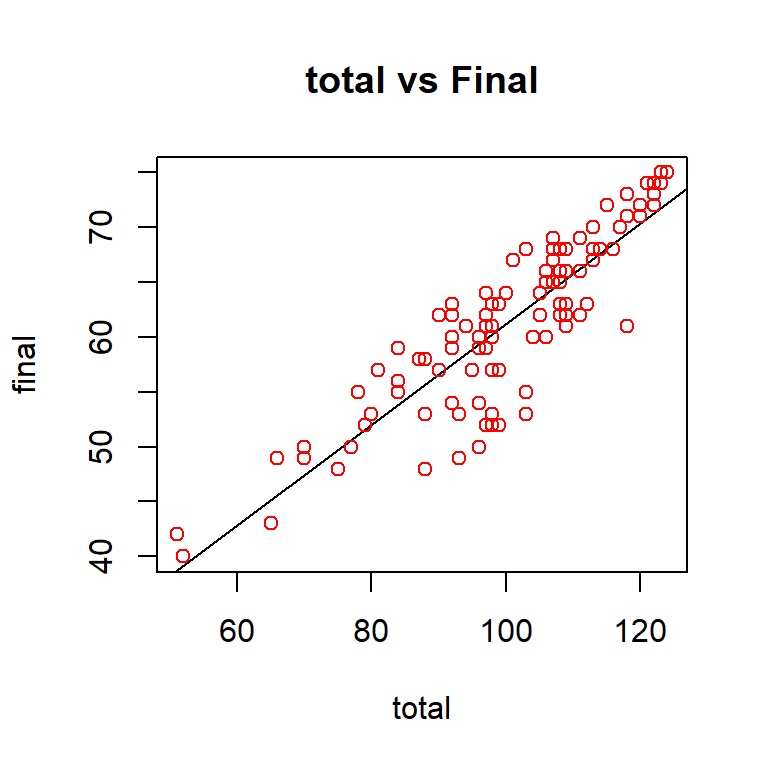

[figure not shown]

#### Now checking Correlation of each of these predictors with the response variable

```r
cor(grades$gpa,grades$final) #correlation between  gpa & final
```

```
## [1] 0.498055
```

```r
cor(grades$quiz1,grades$final) #correlation between  quiz1 & final
```

```
## [1] 0.5350754
```

```r
cor(grades$quiz2,grades$final) #correlation between  quiz2 & final
```

```
## [1] 0.5518668
```

```r
cor(grades$quiz3,grades$final) #correlation between  quiz3 & final
```

```
## [1] 0.5611773
```

```r
cor(grades$quiz4,grades$final) #correlation between  quiz4 & final
```

```
## [1] 0.4878348
```

```r
cor(grades$quiz5,grades$final) #correlation between  quiz5 & final
```

```
## [1] 0.4715109
```

```r
cor(grades$total,grades$final) #correlation between  total & final
```

```
## [1] 0.8826091
```

```r
cor(grades$percent,grades$final)   #correlation between  percent & final
```

```
## [1] 0.8895457
```

We can see that all the predictors are positively Correlated with the final .We can notice that total & percent are the two variables which are highly positively related with final .This is quite obvious as final is a part of the total & percent. Higher the final score higher is total or percent. According to the Scatter plots we can say that the final and preditors are related to each other through a linear line Hence the linearity assumption is true for all. [ Assumption in order to predict the values through Regression model ]

#### Question3. What are R Square and Adjusted R Square of your final model? Show R Output and explain in 3 or 4 lines.Explain the difference between R Square and Adjusted R Square. Which one is superior and why?

```
Answer:
```

There can be various models built based on the predictors available .Let’s start building Linear Regression Models

#### 1. final ~ gpa+quiz1+quiz2+quiz3+quiz4+quiz5

```r
fg12345<-lm(final~gpa+quiz1+quiz2+quiz3+quiz4+quiz5,data=grades)
fg12345
```

```
##
## Call:
## lm(formula = final ~ gpa + quiz1 + quiz2 + quiz3 + quiz4 + quiz5,
##     data = grades)
##
## Coefficients:
## (Intercept)          gpa        quiz1        quiz2        quiz3
##     32.8658       3.6271       0.2986       0.8004       0.9063
##       quiz4        quiz5
##     -0.1428       0.4823
```

```r
summary(fg12345)
```

```
##
## Call:
## lm(formula = final ~ gpa + quiz1 + quiz2 + quiz3 + quiz4 + quiz5,
##     data = grades)
##
## Residuals:
##      Min       1Q   Median       3Q      Max
## -13.6580  -2.7187   0.7985   3.9664  11.4979
##
## Coefficients:
##             Estimate Std. Error t value Pr(>|t|)
## (Intercept)  32.8658     3.3141   9.917  < 2e-16 ***
## gpa           3.6271     0.7879   4.604 1.25e-05 ***
## quiz1         0.2986     0.5162   0.578   0.5643
## quiz2         0.8004     0.6032   1.327   0.1876
## quiz3         0.9063     0.5217   1.737   0.0855 .
## quiz4        -0.1428     0.4739  -0.301   0.7638
## quiz5         0.4823     0.4580   1.053   0.2948
## ---
## Signif. codes:  0 '***' 0.001 '**' 0.01 '*' 0.05 '.' 0.1 ' ' 1
##
## Residual standard error: 5.831 on 98 degrees of freedom
## Multiple R-squared:  0.4922, Adjusted R-squared:  0.4611
## F-statistic: 15.83 on 6 and 98 DF,  p-value: 1.224e-12
```

From the above model we can see that the quiz1,quiz2,quiz3,quiz4,quiz5 have p values which are greater than LOS hence our null hypothesis H0: slope is not significant OR There is no significant Linear relationship with final of these predictors for this Linear Regression model. With this model we can say that the preditors together explain 49.22% variance in the dependent variable final & the value Adjusted R squared of .4611 meaning 46.11% variance an be explained by this model for final. We will not consider this model as it has more predictors and even slope of all the predictors except gpa is not much significant with final Point to be noted is that Quiz3 has nearest signifiant p value close to LOS of 0.05 so we an have quiz3 as a consideration

```r
vif(fg12345)
```

```
##      gpa    quiz1    quiz2    quiz3    quiz4    quiz5
## 1.107509 5.015198 2.931613 4.433567 3.572136 1.999252
```

In this model quiz1 is artifiially increasing the value of R square as its Variance inflation factor is 5.01 whih is quite high so lets remove quiz1 from this model and build another model without quiz1 as predictor

#### 2. final~gpa+quiz2+quiz3+quiz4+quiz5,data=grades

```r
fg2345<-lm(final~gpa+quiz2+quiz3+quiz4+quiz5,data=grades)
summary(fg2345)
```

```
##
## Call:
## lm(formula = final ~ gpa + quiz2 + quiz3 + quiz4 + quiz5, data = grades)
##
## Residuals:
##      Min       1Q   Median       3Q      Max
## -13.5494  -2.7210   0.5787   4.0927  11.5517
##
## Coefficients:
##             Estimate Std. Error t value Pr(>|t|)
## (Intercept) 32.49410    3.24023  10.028  < 2e-16 ***
## gpa          3.62466    0.78519   4.616 1.17e-05 ***
## quiz2        0.82825    0.59928   1.382   0.1701
## quiz3        1.06375    0.44360   2.398   0.0184 *
## quiz4       -0.02019    0.42244  -0.048   0.9620
## quiz5        0.50431    0.45486   1.109   0.2702
## ---
## Signif. codes:  0 '***' 0.001 '**' 0.01 '*' 0.05 '.' 0.1 ' ' 1
##
## Residual standard error: 5.812 on 99 degrees of freedom
## Multiple R-squared:  0.4904, Adjusted R-squared:  0.4647
## F-statistic: 19.06 on 5 and 99 DF,  p-value: 3.089e-13
```

```r
library(car)
vif(fg2345)
```

```
##      gpa    quiz2    quiz3    quiz4    quiz5
## 1.107478 2.912966 3.227419 2.857258 1.985498
```

No high correlation among predictors,but p-values of quiz2,quiz4,quiz5 are high wrt LOs,so we are removing them from this model and making the new model explained just below

#### 3. final~gpa+quiz3,data=grades

```r
fg3<-lm(final~gpa+quiz3,data=grades)
fg3
```

```
##
## Call:
## lm(formula = final ~ gpa + quiz3, data = grades)
##
## Coefficients:
## (Intercept)          gpa        quiz3
##      37.541        3.993        1.609
```

```r
summary(fg3)
```

```
##
## Call:
## lm(formula = final ~ gpa + quiz3, data = grades)
##
## Residuals:
##      Min       1Q   Median       3Q      Max
## -14.5260  -3.2000  -0.0803   4.7388  12.3955
##
## Coefficients:
##             Estimate Std. Error t value Pr(>|t|)
## (Intercept)  37.5415     2.6802  14.007  < 2e-16 ***
## gpa           3.9926     0.7850   5.086 1.67e-06 ***
## quiz3         1.6088     0.2598   6.193 1.26e-08 ***
## ---
## Signif. codes:  0 '***' 0.001 '**' 0.01 '*' 0.05 '.' 0.1 ' ' 1
##
## Residual standard error: 5.929 on 102 degrees of freedom
## Multiple R-squared:  0.4535, Adjusted R-squared:  0.4428
## F-statistic: 42.32 on 2 and 102 DF,  p-value: 4.133e-14
```

In this model the p-value of both gpa & quiz3 is less than LOS(alpha=0.05) meaning slope of both are significant with the dependent variable.Moreover, as we need to take least variables in our model gpa & quiz3 are giving us 45.35% explanation in variance of final, so this model is one of the best models to be considered as the preditor model for the predition of response variable final .

```r
vif(fg3)
```

```
##     gpa   quiz3
## 1.06341 1.06341
```

Both the preditors here have the same Variance inflation fator but they are not greatly correlated as VIF around is 1.06.

As gpa is also obtained by taking into consideration all the marks in quiz 1-5 and final and total.So taking GPa as a predictor needs the principal to have GPA scores readily available with her for predicting final scores(used to alculate gpa). (Principal can predict through the model of GPA for future students that a student with assumed GPA will have predicted final score within this partiular range) The Linear Regression model that can be considered best for prediticng final will be final~gpa+quiz3 . This model will give a prediction of final based (on actual gpa & quiz3- for students with data available ) or (on assumed gpa and quiz 3 score -for future students) .This model hels us explain the variance in final with 45.35 %. This model an be used to predict Final using GPA & quiz 3

#### 4. final~total+quiz3,data=grades

```r
ft3<-lm(final~total+quiz3,data=grades)
ft3
```

```
##
## Call:
## lm(formula = final ~ total + quiz3, data = grades)
##
## Coefficients:
## (Intercept)        total        quiz3
##       6.674        0.695       -1.892
```

```r
summary(ft3)
```

```
##
## Call:
## lm(formula = final ~ total + quiz3, data = grades)
##
## Residuals:
##     Min      1Q  Median      3Q     Max
## -8.7702 -1.5943  0.4497  2.1800  4.9337
##
## Coefficients:
##             Estimate Std. Error t value Pr(>|t|)
## (Intercept)  6.67358    2.11542   3.155  0.00211 **
## total        0.69502    0.03282  21.180  < 2e-16 ***
## quiz3       -1.89162    0.21754  -8.696 6.19e-14 ***
## ---
## Signif. codes:  0 '***' 0.001 '**' 0.01 '*' 0.05 '.' 0.1 ' ' 1
##
## Residual standard error: 2.857 on 102 degrees of freedom
## Multiple R-squared:  0.8731, Adjusted R-squared:  0.8706
## F-statistic: 350.8 on 2 and 102 DF,  p-value: < 2.2e-16
```

```r
vif(ft3)
```

```
##    total    quiz3
## 3.210517 3.210517
```

The Best Linear Regression model with condition can have total as a preditor of final scores for the students(who have got scores in all the quiz1-5, final and have gpa available-hence total available with them) or( future students- who dont have any score available with them and an assumption based on estimated total and quiz3 score will predict final score for the students) . Principal can predict using this model that a student with total & quiz3 must have a final score in a particular range. The Linear Regression of total combined with quiz3 will give us explanation of 87.31% of variance in final (y) . For future students who donot have total score available with them cannot use this model to predict final score obviously as they don’t have total sores available with them. But Prinipal an take an idea that for future students for this much total & quiz3 score student final score can be predicted and will lie in a partiulatar range as predicted by the model with 87.31% variance in final explained .Moreover for this model vif is not artificially being increased by any of these two predictors.

#### 5. final~quiz2+quiz3,data=grades

Best modelobtained by considering the score in quiz1 to quiz5 only and no total no perent or gpa are obtained or be predicted . Wewill use the below model to predict the final score

```r
f23<-lm(final~quiz2+quiz3,data=grades)
summary(f23)
```

```
##
## Call:
## lm(formula = final ~ quiz2 + quiz3, data = grades)
##
## Residuals:
##     Min      1Q  Median      3Q     Max
## -15.441  -3.720   1.030   4.931   9.839
##
## Coefficients:
##             Estimate Std. Error t value Pr(>|t|)
## (Intercept)  39.7129     3.1398  12.648  < 2e-16 ***
## quiz2         1.5407     0.5311   2.901  0.00456 **
## quiz3         1.1862     0.3735   3.176  0.00198 **
## ---
## Signif. codes:  0 '***' 0.001 '**' 0.01 '*' 0.05 '.' 0.1 ' ' 1
##
## Residual standard error: 6.381 on 102 degrees of freedom
## Multiple R-squared:  0.3671, Adjusted R-squared:  0.3547
## F-statistic: 29.59 on 2 and 102 DF,  p-value: 7.359e-11
```

```r
vif(f23)
```

```
##    quiz2    quiz3
## 1.897984 1.897984
```

In this model considering quiz2 & quiz3 exams which happens before the final exams can together help us explain 36.71% variance in the final As p value of both is less than LOS(0.05) so we can say that both quiz2 & quiz3 are signinficantly related to final(depedent variable) .

#### 6. final3~quiz3

```r
f3<-lm(final~quiz3,data=grades)
summary(f3)
```

```
##
## Call:
## lm(formula = final ~ quiz3, data = grades)
##
## Residuals:
##      Min       1Q   Median       3Q      Max
## -15.3759  -4.3759   0.5556   5.6241  11.5556
##
## Coefficients:
##             Estimate Std. Error t value Pr(>|t|)
## (Intercept)  46.0613     2.3312  19.759  < 2e-16 ***
## quiz3         1.9315     0.2807   6.881 4.76e-10 ***
## ---
## Signif. codes:  0 '***' 0.001 '**' 0.01 '*' 0.05 '.' 0.1 ' ' 1
##
## Residual standard error: 6.607 on 103 degrees of freedom
## Multiple R-squared:  0.3149, Adjusted R-squared:  0.3083
## F-statistic: 47.35 on 1 and 103 DF,  p-value: 4.758e-10
```

In this model around 31.49% of variance in final is explained by quiz3 alone. Hence We can consider it as an average to good predictor model.

[output not shown]

The Formula for R-squared Value is given by SSR/SST which can be reduced to R-Squared = 1 - SSE/SST

```
####Adj- R Squared = [ 1 - (SSE/degree of freedom of residuals)/( SST /df of model) ]

Hence the formula is reduced to

####Adj- R Squared= [ 1 -  (SSE/n-k-1)/( SST n-1) ]
```

Out of R-Squared value & Adjusted R-Squared value , Adjusted R squared value can be considered more superior, As it takes into consideration the predictors of the model while calculating the variance for the dependent variable .R-Squared value suppose that every independent variable is responsible for some variation in the dependent variable whereas Adjusted R - Squared Value gives the percentage for those independent variables which in actual effects the Dependent variable. R-squared measures the proportion of the variation in the dependent variable (Y) explained by the independent variables (X) for a linear regression model whereas, Adjusted R-squared adjusts the statistic based on the number of independent variables in the model. Although there is very less difference in the value of both, so we can consider any one for our consideration.

#### Question 4. How do you interpret significance value of F-statistics? Mention in few lines and show R Output ?

```
Answer:
```

Significance value of F Statistics basically indicates the fit of the Overall Linear regression model built..It tells us whether the model provides a better fit to the data than a model that has no independent variable (in which we take the mean as the only data predicting point) .This test is basically the Hypothesis test for relationship.

The F-test uses its p-value for overall significance has 2 hypothesis : . H0: there is no significant relationship i.e Slope of population is “0” . Ha: there is significant relationship .i.e slope of Population is not “0” We compare the p-value of the F-test with LOS(alpha) i.e Level of significance . If p value is less than alpha we can come to the conclusion that the regression model fits the data better as H0 will be rejected and Ha will be accepted. It also mean the model is adding significant predictability for variable y by x

But if p-value of F-test is more than Level of significance we can conclude that our regression model is not significant . Now we have two models for whih the assumptions are to be checked the name of the models are f23 & ft3

```r
summary(f23)
```

```
##
## Call:
## lm(formula = final ~ quiz2 + quiz3, data = grades)
##
## Residuals:
##     Min      1Q  Median      3Q     Max
## -15.441  -3.720   1.030   4.931   9.839
##
## Coefficients:
##             Estimate Std. Error t value Pr(>|t|)
## (Intercept)  39.7129     3.1398  12.648  < 2e-16 ***
## quiz2         1.5407     0.5311   2.901  0.00456 **
## quiz3         1.1862     0.3735   3.176  0.00198 **
## ---
## Signif. codes:  0 '***' 0.001 '**' 0.01 '*' 0.05 '.' 0.1 ' ' 1
##
## Residual standard error: 6.381 on 102 degrees of freedom
## Multiple R-squared:  0.3671, Adjusted R-squared:  0.3547
## F-statistic: 29.59 on 2 and 102 DF,  p-value: 7.359e-11
```

```r
summary(ft3)
```

```
##
## Call:
## lm(formula = final ~ total + quiz3, data = grades)
##
## Residuals:
##     Min      1Q  Median      3Q     Max
## -8.7702 -1.5943  0.4497  2.1800  4.9337
##
## Coefficients:
##             Estimate Std. Error t value Pr(>|t|)
## (Intercept)  6.67358    2.11542   3.155  0.00211 **
## total        0.69502    0.03282  21.180  < 2e-16 ***
## quiz3       -1.89162    0.21754  -8.696 6.19e-14 ***
## ---
## Signif. codes:  0 '***' 0.001 '**' 0.01 '*' 0.05 '.' 0.1 ' ' 1
##
## Residual standard error: 2.857 on 102 degrees of freedom
## Multiple R-squared:  0.8731, Adjusted R-squared:  0.8706
## F-statistic: 350.8 on 2 and 102 DF,  p-value: < 2.2e-16
```

```
####For f23 our F-test has p-value which is equal to  7.359e-11 which is almost '0' hence we reject our null Hypothesis for that model is rejected meaning F-statistic value of 29.59 is significant fit for our model

####For ft3 our F-test  has p-value which is equal to  2.2e-16 which is almost '0' hence we reject our null Hypothesis for that model is rejeted meaning F-statistic value of 350.8 is significant fit for our model
```

#### Question 5. Use equation writer & Write Regression equation of the best model. Show R Output.

```
Answer.
```

The Equation for our models are as follows

For Model ft3 the equation of the regression line is given by

```
final = 6.67358 + (0.69502*total) - (1.89162*quiz3)
```

For Model f23 the equation of the regression line is given by

[output not shown]

#### Question6. What is Durbin Watson Statistics of your model? How DWS is interpreted? Show how do you find dL and dU and design four boundaries in the sample diagram .Show R Output also.

```
Answer :
```

### Let’s find Durbin Watson Test for our two models

```
For ft3 durbin watson Statistics comes out to be 2.115215
```

```r
dwt(ft3)
```

```
##  lag Autocorrelation D-W Statistic p-value
##    1     -0.07657619      2.115215    0.54
##  Alternative hypothesis: rho != 0
```

```
For f23 durbin watson Statistics comes out to be 2.233423
```

```r
dwt(f23)
```

```
##  lag Autocorrelation D-W Statistic p-value
##    1      -0.1209658      2.233423   0.262
##  Alternative hypothesis: rho != 0
```

The DWS statistics is the number that tests the autocorrelation in the errors/residuals from a regression analysis. It’s value will always lie between “0 & 4”" .DWS value of ‘2’ means there is no autocorrelation in the sample,whereas value towards “zero” from ‘2’ means there is +ve autocorrelation & “towards 4”" from ‘2’ means -ve autocorrelation. Autocorrelation is a characteristic of data in which the correlation between the values of the same variables is based on related objects. In this dataset Autocorrelation for variable ‘final’ it means that the marks of student 2 in final depends on the marks of student 1 in final and that of student 3 in final depends on the marks of student 2 in final and so on. If such autocorrelation occurs we should not build a Linear regression model for our model and we just need to move to time analysis Model.

The formula for DWS is [summation {E(i)- E(i-1)^2} / summation {E(i)^2} ] , which is quite complex .Here ei means the expected value based on the regression equation which we have generated . As number of predictors in our model is 2 hence we need to look at the table for DWS with n= 105 & k=2 to obtain dl & du. We need to find these value using the table with alpha=0.05 . We get the value of dl= 1.63 & du = 1.72

#### How to interpret Durbin Statistics Value

After finding the dl & du value we place them on the scale of Durbin Watson .If the value of DWS we found or our model is lying between the zone of “No auto correlation” than we can be sure of “no autocorrelation” & hence we can proceed with the Linear Regression Model. If the value of DWS lies in Positive or Negative range of the scale than for sure Linear Regression model cannot be applied as it shows there is relationship between the observation values. Now if it comes in Indecisive zone the benefit of the doubt goes with the Researcher. Most of the times,he continues with the Linear Regression model results. As our Durbin statistics is “2.11 for ft3 model” & “2.23 for f23 model” both of which lies in No-Autocorrelation region we can say that there is no-autocorrelation and thus we can proceed further with the results of Linear regression models.

#### Question 7. What is VIF for each predictor/s? How do you interpret VIF or what VIF signifies? Max 5 lines. [VIF (Variance Inflation Factor) Show R Output. ?

```
Answer :
```

VIF means Variance Inflation factor This inflation factor is basically used to calculate the multi-collinearity between the predictors.If VIF of 2 or more predictors/variables is more than 5 generally it means they are highly correlated,we can remove any one/more of them which we feel is less significant for the model .It is a simple approach to identify collinearity among explanatory variables.

VIF calculations are straightforward and easily comprehensible; the higher the value, the higher the collinearity. A VIF for a single explanatory variable is obtained using the r-squared value of the regression of that variable against all other explanatory variables.

In our model ft3 & f23 VIFs for preditors is as below

```
For ft3 model
```

```r
vif(ft3)
```

```
##    total    quiz3
## 3.210517 3.210517
```

```
For f23 model
```

```r
vif(f23)
```

```
##    quiz2    quiz3
## 1.897984 1.897984
```

#### Finding the predicted Value of final through both the models made

```
1.  For ft3 model
```

```r
grades$predft3<-predict(ft3)
grades$predft3
```

```
##   [1] 49.03415 60.15453 59.65296 65.01969 64.71158 72.55029 65.60005
##   [8] 71.16024 73.24531 75.83195 62.74117 69.77019 64.90503 57.48909
##  [15] 48.33912 60.65610 63.04928 56.48595 65.32781 61.42991 57.10219
##  [22] 66.99010 57.76134 67.29822 44.28365 61.65924 62.81996 71.16024
##  [29] 53.51241 69.77019 57.06632 59.34484 54.47967 63.51498 57.37443
##  [36] 59.34484 57.76134 60.15453 58.45636 73.24531 53.70586 58.26291
##  [43] 70.07831 73.94034 61.93148 42.81481 56.48595 59.65296 71.85526
##  [50] 63.43619 73.24531 65.90817 47.45065 69.18983 38.33655 62.81996
##  [57] 54.59434 59.26605 72.55029 55.79093 55.59748 54.09277 68.18669
##  [64] 62.81996 62.62650 57.37443 57.06632 62.62650 65.21315 58.45636
##  [71] 64.90503 67.10476 63.82310 49.65038 46.87029 72.55029 69.07517
##  [78] 63.51498 59.26605 55.86972 64.90503 66.29508 68.38015 53.78465
##  [85] 66.60319 69.77019 54.28622 63.51498 64.82624 59.76762 69.77019
##  [92] 56.56475 71.16024 64.01655 55.17470 69.57674 63.62964 61.42991
##  [99] 52.39460 62.12493 62.74117 49.65038 48.84069 63.51498 64.01655
```

```
2.  For f23 model
```

```r
grades$predf23<-predict(f23)
grades$predf23
```

```
##   [1] 55.71974 63.42344 59.98739 60.34196 62.71430 66.98195 65.44121
##   [8] 65.44121 66.98195 65.79578 59.15579 66.98195 63.90047 56.78345
##  [15] 55.71974 59.15579 55.24271 60.69653 59.51036 65.44121 51.32963
##  [22] 63.90047 65.79578 63.06887 52.16123 52.16123 63.90047 66.98195
##  [29] 54.88814 65.44121 61.17356 66.98195 65.44121 63.90047 58.80122
##  [36] 66.98195 59.63282 57.26048 62.71430 66.98195 57.61505 58.44665
##  [43] 61.52813 66.98195 64.25504 47.41656 54.53357 61.52813 65.44121
##  [50] 57.61505 66.98195 61.52813 54.53357 60.34196 46.70741 63.90047
##  [57] 57.26048 57.61505 66.98195 57.61505 57.96962 59.98739 64.25504
##  [64] 65.44121 64.25504 58.80122 62.71430 64.25504 58.44665 61.17356
##  [71] 65.44121 60.34196 64.60961 52.51580 50.97506 66.98195 65.44121
##  [78] 65.44121 54.53357 66.98195 65.44121 65.44121 63.90047 60.81899
##  [85] 63.06887 66.98195 62.71430 65.44121 59.15579 57.96962 65.44121
##  [92] 66.98195 65.44121 64.25504 63.90047 65.79578 58.80122 65.44121
##  [99] 66.98195 62.35973 59.15579 52.51580 54.53357 65.44121 62.71430
```

#### Question 8. How do you interpret the significance of slope of predictors based on sig. Value or p-value associated with t-statistics of each predictor/s. [testing of slope] Show R Output. ?

```
Answer:
```

```r
summary(ft3)
```

```
##
## Call:
## lm(formula = final ~ total + quiz3, data = grades)
##
## Residuals:
##     Min      1Q  Median      3Q     Max
## -8.7702 -1.5943  0.4497  2.1800  4.9337
##
## Coefficients:
##             Estimate Std. Error t value Pr(>|t|)
## (Intercept)  6.67358    2.11542   3.155  0.00211 **
## total        0.69502    0.03282  21.180  < 2e-16 ***
## quiz3       -1.89162    0.21754  -8.696 6.19e-14 ***
## ---
## Signif. codes:  0 '***' 0.001 '**' 0.01 '*' 0.05 '.' 0.1 ' ' 1
##
## Residual standard error: 2.857 on 102 degrees of freedom
## Multiple R-squared:  0.8731, Adjusted R-squared:  0.8706
## F-statistic: 350.8 on 2 and 102 DF,  p-value: < 2.2e-16
```

```r
summary(f23)
```

```
##
## Call:
## lm(formula = final ~ quiz2 + quiz3, data = grades)
##
## Residuals:
##     Min      1Q  Median      3Q     Max
## -15.441  -3.720   1.030   4.931   9.839
##
## Coefficients:
##             Estimate Std. Error t value Pr(>|t|)
## (Intercept)  39.7129     3.1398  12.648  < 2e-16 ***
## quiz2         1.5407     0.5311   2.901  0.00456 **
## quiz3         1.1862     0.3735   3.176  0.00198 **
## ---
## Signif. codes:  0 '***' 0.001 '**' 0.01 '*' 0.05 '.' 0.1 ' ' 1
##
## Residual standard error: 6.381 on 102 degrees of freedom
## Multiple R-squared:  0.3671, Adjusted R-squared:  0.3547
## F-statistic: 29.59 on 2 and 102 DF,  p-value: 7.359e-11
```

The interpretation of significance of the slope of the predictors based on significance value or p-value associated with the t statistics is comparing it with the level of Significance.

A t-test is always associated with a hypothesis testing.In the Regression analysis a t-test is done for testing the slope of the predictor whether it has any significant relation with the dependent variable or not .and this t-test has p value associated with it which is compared with the LOS(alpha) So this interpretation tells us whether slope of predictor has some linear relationship with response variable or not.

The hypothesis associated with the testing of the slope is as follows for Simple Regression . Ho: Beta1=0 , there is no significant relationship of slopeof predictor . Ha: Beta1 != zero, there is significant relationship with slope of that predictor

The hypothesis associated with the testing of the slope is as follows for multiple Regression . Ho: Beta1=0 , there is no significant relationship . Ha: at least one slope of one predictor is not equal to “zero”, there is significant relationship with slope of that predictor

Significance value or p-value for our t-test is used for the above hypothesis testing for slope test . If we get to know that the p-value > LOS(alpha=0.05) then null hypothesis will be accepted and it will mean that slope of that variable has no significant effect on the dependent variable & if we p-value< LOS(alpha=0.05) ,we reject the null hypothesis meaning that there is significant relationship between them

For our Model “ft3” the value of Pr(>|t|) or p-value for our predictor total is 2e-16 & for quiz3 is 6.19e-14 .Both almost equal to “zero” and less than LOS meaning both the predictors have significant slope for our model ( p-value< LOS (alpha=0.05))

For our Model “f23” the value of Pr(>|t|) or p-value for our predictor quiz2 is 00456 & for quiz3 is 0.00198 .Both less than LOS meaning both the predictors have significant slope for our model.( p-value< LOS (alpha=0.05))

#### error values of final through the models are below. These values are giving us the residuals of our model

```
1. For Model ft3
```

```r
grades$errft3<-residuals(ft3)
grades$errft3
```

[output not shown]

```
2.  For Model f23
```

```r
grades$errf23<-residuals(f23)
grades$errf23
```

[output not shown]

#### Adding observation no.s against each row in the data set grades

```r
grades$obsno<-c(1:105)
grades$obsno
```

[output not shown]

##### The equations of the model which are built as the best or final Models are

[output not shown]

#### predicted values of final models using the above equations are below. These values are giving us the predited value of our model

For model ft3,inserting the predicted values in the grades dataset by column creation

```r
predft3<-predict(ft3)
grades$predft3<-predft3
grades$predft3
```

[output not shown]

```
*For Model f23,inserting the predicted values in the grades dataset  by column creation
```

```r
predft3<-predict(ft3)
grades$predft3<-predft3
grades$predf23
```

[output not shown]

#### Question 9. Test the assumption of Normality and interpret your findings. .Show histogram and interpret in maximum 3 lines.

```
Answer :
```

### Assumptions Test for ft3 & f23 Models

#### 1. Normality test for ft3 & f23

```
*For Ft3 & F23 let us draw  histogram for both the models of errors
```

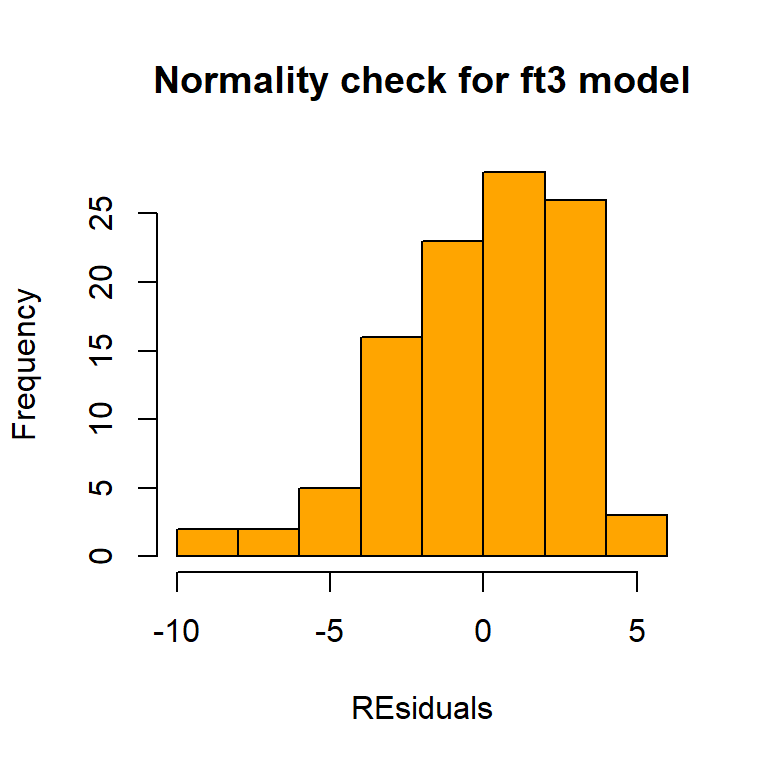

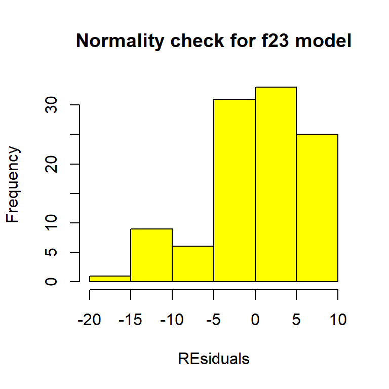

In both the models the data is almost normally distributed but little skewed towards the left.It means it is a bit left skewed. But we an consider that the assumption of normality does hold.

#### Question 10. Test the assumption of Independent of observations and interpret in maximum 3 lines

```
Answer :
```

### Assumptions Test for ft3 & f23 Models

#### 2. Independent of observations

```
*For Ft3 & F23 let us draw  scatter pot  for residulas & the Observations the models of errors
```

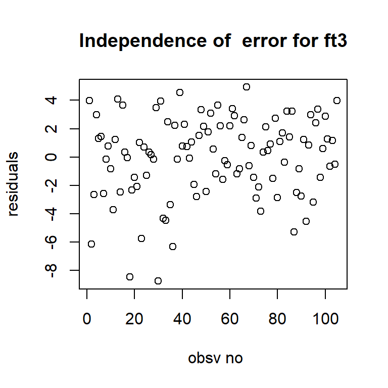

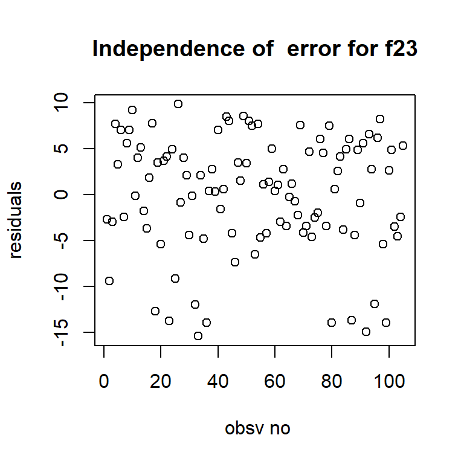

#### Question 11. Test the assumption of linear relationship and interpret in maximum 3 lines for each predictor . If more than one predictor is used in model then more scatter plots would be required]

```
Answer :
```